# Solutions 16: Error Assumptions

Author

Affiliation

Adam Spiegler

University of Colorado Denver

## Additional Reading

- See *Linear Regression Models: Applications in R* ([link to library ebook](https://go.exlibris.link/Q7wgCRrz))
  - Chapter 8 covers uncorrelated errors assumption.
  - Chapter 9 covers constant variance assumption.
  - Chapter 11 covers normality.
- Chapter 9 of *Applied Linear Regression* ([link to library ebook](https://go.exlibris.link/69jsQwWW))
- [Chapter 5: Basic theoretical results](https://jfrench.github.io/LinearRegression/linear-model-theory.html#standard-assumptions) from *A Progressive Introduction to Linear Models*

# Loading Required Packages and Data

```r
library(tidyverse)
library(lmtest)  # to access dwtest
library(car)  # for residualPlots and qqPlot
```

# Standard Assumptions Revisited

There are several standard assumptions made when performing linear regression that we have discussed so far.

1. Assumption for $\mathbf{y}$: $E( \mathbf{y} \ | \ X ) = X \boldsymbol\beta$.
2. Assumptions for $\boldsymbol{\epsilon}$: $\epsilon_1, \epsilon_2, \ldots , \epsilon_n \overset{\mbox{i.i.d.}}{\sim} N(0, \sigma^2)$.
- $E(\epsilon \ | \ \mathbb{X})=0$ (essentially same as assumption 1)
- $\mbox{Var}(\epsilon \ | \ \mathbb{X} ) = \sigma^2$.
- $\mbox{Cov}( \epsilon_i , \epsilon_j \ | \ \mathbb{X}) = 0$ for all $i \ne j$
- Each of the errors, regardless of the regressor values, are normally distributed.

## Question 1

Interpret the assumptions above in more practical terms, that a non-technical colleague could better understand.

### Solution to Question 1

1. The average value of $\mathbf{y}$ is linearly related to the regressors. Thus, we expect the model to give predictions which on average, equal the true values. This is equivalent to saying the model is correctly specified. This means there are no missing or extra regressors in our regression equation.
- The model unbiased regardless of the observed values of the predictors. In other words, on the average value of an error is 0.
- The spread or variability in the errors is constant regardless of the values of the predictors that we observe.
- he error in one prediction in unrelated to the errors of all other predictions.
- We expect most of our errors to be close to 0. The likelihood of getting a large error gets less and less as the error gets larger. We are equally likely to have over-estimates as we are under-estimates.

## Practical Considerations

3. The columns of $\mathbf{X}$ are linearly independent, i.e., none of the regressors are linear combinations of each other. This assumption is checking by assessing **whether collinearity is present**. This assumption is critical for ensuring that our model is identifiable.
4. **No observations are substantially more influential than other observations** in determining the fit of the model to the observed data. Influential observations can make it difficult to determine whether Assumptions 1 and 2 are satisfied.

## Question 2

Consider the residual plots (a)-(h) in the figure below. For each plot, determine which of the **error assumptions** seem to be satisfied.

**Note**

Disregard the normality assumption for now since that will be easier to assess using a Q-Q plot.

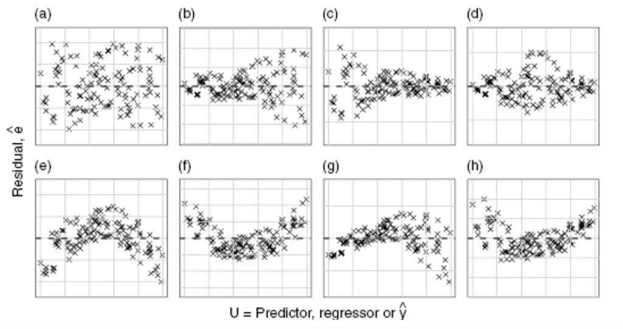

Residual Plots

## Solution to Question 2

1. All error assumptions are satisfied.

b, c and d: Mean error zero (linearity) is satisfied. Hard to determine whether or not the errors are uncorrelated. The variance is clearly not constant.

e and f: Constant variance is satisfied. The mean error zero is not satisfied. The relation appears to be non-linear (quadratic?). The errors are correlated.

g and h: None of the assumptions seem to be satisfied. The mean error zero is not satisfied. The relation appears to be non-linear (quadratic?). The variance is not constant. The errors are correlated.

## Standard Assumptions Prioritized

We assume that any issues with collinearity and identifiability (Assumption 3) have already been addressed. We have discussed this process.

1. **The structure of the model is correct (Assumption 1).** If the structure of your model is incorrect, then no conclusions drawn from our model are trustworthy.
2. **No points are overly influential in determining the model fit (Assumption 4).** An overly influential observation can make it seem like the model is correctly specified when it is not.
3. **The errors have constant variance (Assumption 2).** If this assumption isn’t satisfied, then standard confidence intervals for the regression coefficients and mean function and prediction intervals for new observations are not trustworthy.
4. **The errors are uncorrelated (Assumption 2).**
5. **The errors are normally distributed (Assumption 2).** This is the least important assumption. If the previous assumptions are satisfied, then our OLS estimator of $\beta$ is still the best linear unbiased estimator regardless of the normality of the errors.
- If the sample size is large enough, the central limit theorem tells us that our confidence intervals for the regression coefficients and the mean function are still approximately valid.
- However, if our sample size is small or we are interested in constructing a prediction interval, then non-normal errors can lead to untrustworthy confidence and prediction intervals.

# Checking Error Assumptions with Residuals

Assumptions for $\boldsymbol\epsilon$ are tricky to check because **$\boldsymbol\epsilon$ is not observed**. The residuals are NOT interchangeable with the errors and have different properties.

- Assumptions for $\boldsymbol\epsilon$ allow us to derive expected properties for our residuals, $\hat{\boldsymbol\epsilon}$. For example:
- $E(\widehat{\boldsymbol{\epsilon}}) = 0$.
- $\mbox{Var}(\widehat{\boldsymbol{\epsilon}}) = \sigma^2 (\mathbf{I} - \mathbf{H})$.
- Assumptions for $\boldsymbol\epsilon$ are checked using $\hat{\boldsymbol\epsilon}$.
- If the observed residual behavior doesn’t match the expected behavior, we believe this was caused by a violation of the relevant error assumption.

## Properties of OLS Residuals

Some facts about the OLS residuals (assuming $y= X \boldsymbol{\beta} + \boldsymbol{\epsilon}$):

- The residuals are an **unbiased** estimator for the true error.
  - If $E(\boldsymbol\epsilon |X)=0$, then $E(\hat{\boldsymbol\epsilon} |X)=0$.
- If an intercept is included in the fitted model, then $\sum \hat{\epsilon}_i=0$.
- We can calculate the variance of the residuals.
  - Note from below that although the variance of the errors is constant, this is not the case for the residuals.

$$\mbox{Var} (\hat{\boldsymbol\epsilon} \ | \ X) = \sigma^2 (I_n-H), \quad \mbox{where} \quad H= X(X^T X)^{-1} X^T \mbox{ is the hat matrix.}$$

- If $E(\boldsymbol{\epsilon} | X)= \mathbf{0}$ and $\mbox{Var}(\boldsymbol{\epsilon} | X)=\sigma^2 I_n$, then $\mbox{Cov}(\hat{\boldsymbol\epsilon} ,\hat{y} | X) =0_{n \times n}$.
- If $\boldsymbol\epsilon |X \sim N(0,\sigma^2 I_n)$, then $\hat{\boldsymbol\epsilon} |X \sim N(0,\sigma^2 (I_n-H))$.
- If $X_j$ is the $j^{\mbox{th}}$ (observed) regressor, then $\mbox{Cov}(\hat{\boldsymbol\epsilon} ,X_j \ | \ X)=0$.

# Motivating Example

The dataset `savings` in the `faraway` package contains savings data from 50 different countries. The variables in the dataset are:

- `sr` is the savings rate, personal saving divided by disposable income.
- `pop15` is the percent of the population under age of 15.
- `pop75` is the percent of the population over age of 75.
- `dpi` is the per-capita disposable income in dollars.
- `ddpi` is the percent growth rate of dpi.

```r
data(savings, package = "faraway") # load data
summary(savings)
```

```
       sr             pop15           pop75            dpi
 Min.   : 0.600   Min.   :21.44   Min.   :0.560   Min.   :  88.94
 1st Qu.: 6.970   1st Qu.:26.21   1st Qu.:1.125   1st Qu.: 288.21
 Median :10.510   Median :32.58   Median :2.175   Median : 695.66
 Mean   : 9.671   Mean   :35.09   Mean   :2.293   Mean   :1106.76
 3rd Qu.:12.617   3rd Qu.:44.06   3rd Qu.:3.325   3rd Qu.:1795.62
 Max.   :21.100   Max.   :47.64   Max.   :4.700   Max.   :4001.89
      ddpi
 Min.   : 0.220
 1st Qu.: 2.002
 Median : 3.000
 Mean   : 3.758
 3rd Qu.: 4.478
 Max.   :16.710
```

```r
lmod <- lm(sr ~ ., data = savings) #fit full model
summary(lmod)
```

```
Call:
lm(formula = sr ~ ., data = savings)

Residuals:
    Min      1Q  Median      3Q     Max
-8.2422 -2.6857 -0.2488  2.4280  9.7509

Coefficients:
              Estimate Std. Error t value Pr(>|t|)
(Intercept) 28.5660865  7.3545161   3.884 0.000334 ***
pop15       -0.4611931  0.1446422  -3.189 0.002603 **
pop75       -1.6914977  1.0835989  -1.561 0.125530
dpi         -0.0003369  0.0009311  -0.362 0.719173
ddpi         0.4096949  0.1961971   2.088 0.042471 *
---
Signif. codes:  0 '***' 0.001 '**' 0.01 '*' 0.05 '.' 0.1 ' ' 1

Residual standard error: 3.803 on 45 degrees of freedom
Multiple R-squared:  0.3385,    Adjusted R-squared:  0.2797
F-statistic: 5.756 on 4 and 45 DF,  p-value: 0.0007904
```

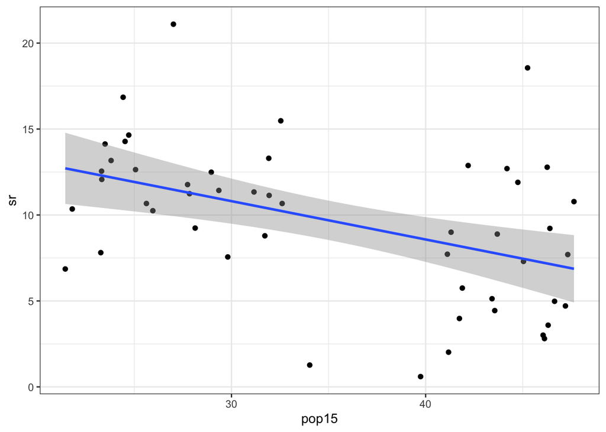

```r
ggplot(savings, aes(x = pop15, y = sr)) +
  geom_point() +
  geom_smooth(method = "lm") +
  theme_bw()
```

# Checking the Mean Zero Error Assumption

## Plotting Residuals Against Fitted Values

The most useful diagnostic is a plot of $\hat{\boldsymbol\epsilon}$ against $\hat{\mathbf{y}}$.

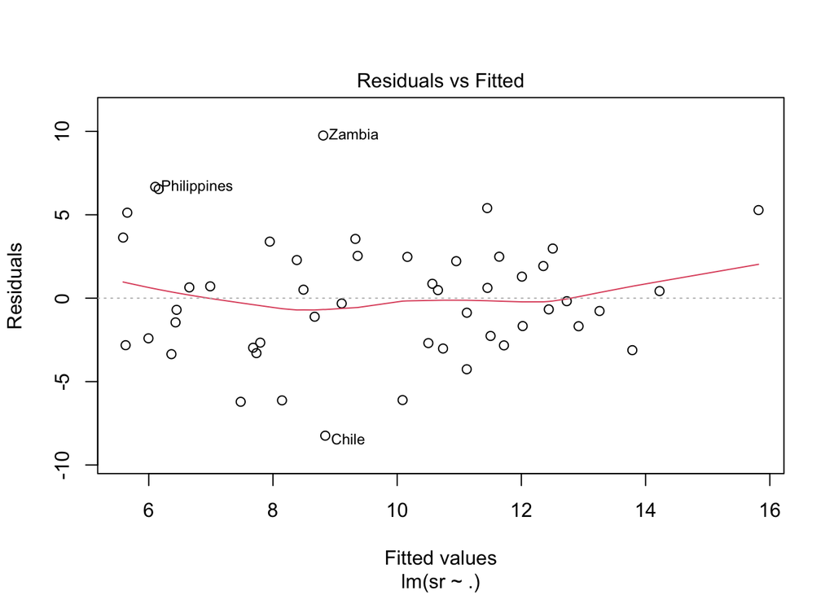

```r
# plot of residuals versus fitted values
plot(lmod, which = 1)
```

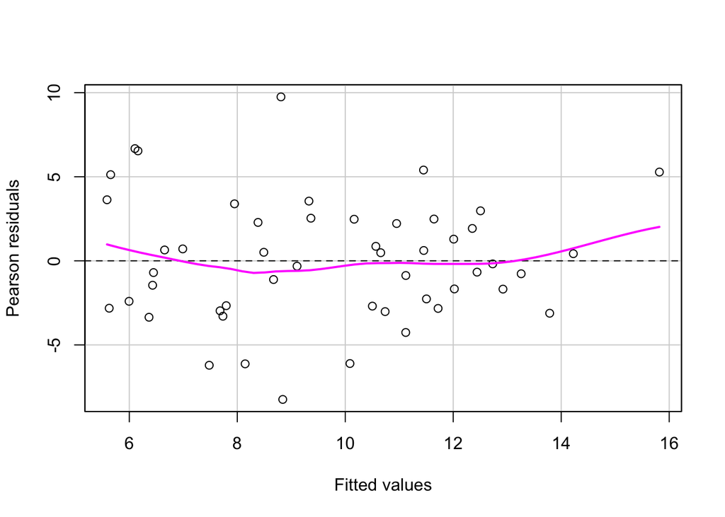

```r
# using residualPlot from car package
residualPlot(lmod, quadratic = FALSE, smooth = TRUE)
```

## Question 3

Based on the residual plot above, does it seem like the mean error assumption is satisfied?

### Solution to Question 3

- We don’t see any reason for concern since the errors that are above the horizontal line through 0 seem to cancel out the errors below the line.
- Smoothers can sometimes reveal patterns in the residuals that would not otherwise be perceived.

## Plotting Residuals Against Regressor Values

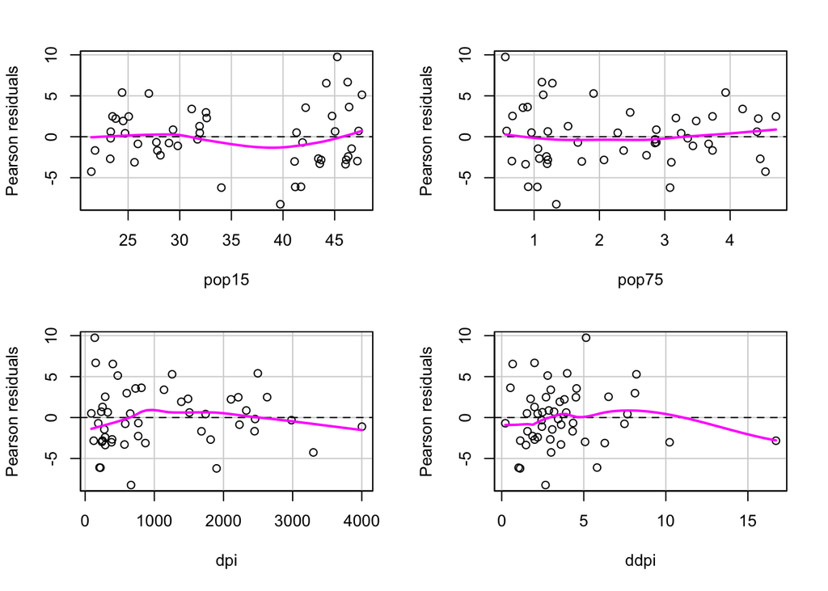

```r
# plot of residuals versus each regressor
residualPlots(lmod,
              quadratic = FALSE,  # don't compare with quad model
              fitted = FALSE,  # do NOT plot residuals vs fitted
              smooth = TRUE,  # include a smoother
              tests = FALSE)  # turn off summary output
```

# Checking the Constant Variance Assumption

- Constant, symmetrical variation in the vertical direction is known as **homoscedasticity**.
- Non-constant variance is called **heteroscedasticity**

## Question 4

Consider the plots below. Comment on which seem to have constant variance, strong non-constant variance, mild nonconstant variance, or have nonlinearity.

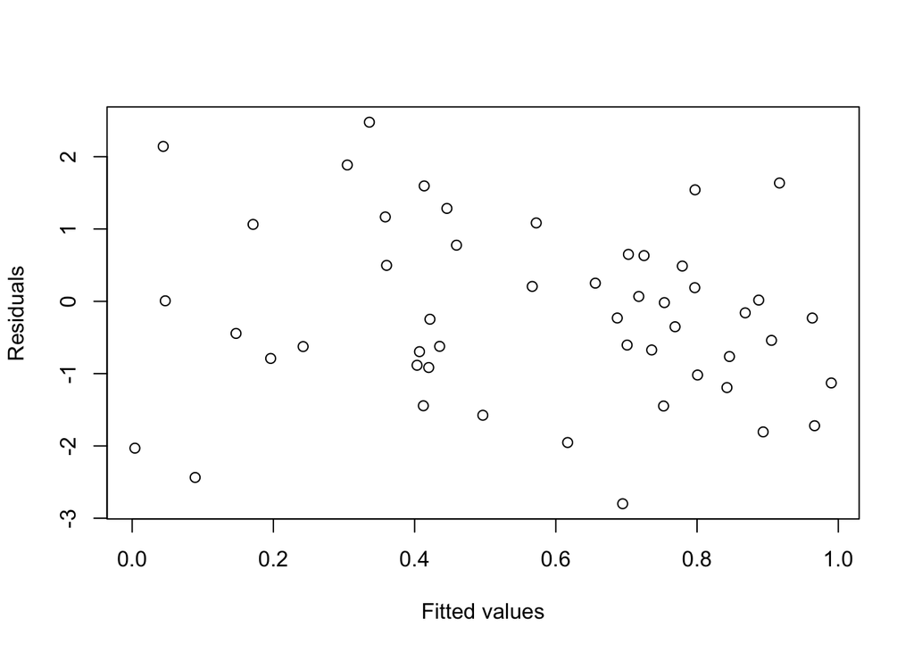

```r
set.seed(118)
n <- 50
x <- runif(n)
plot(x,rnorm(n), xlab = "Fitted values", ylab = "Residuals")
```

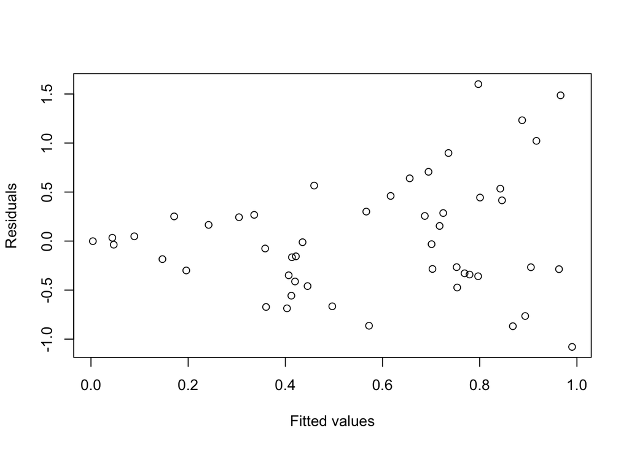

```r
plot(x,x*rnorm(n), xlab = "Fitted values", ylab = "Residuals")
```

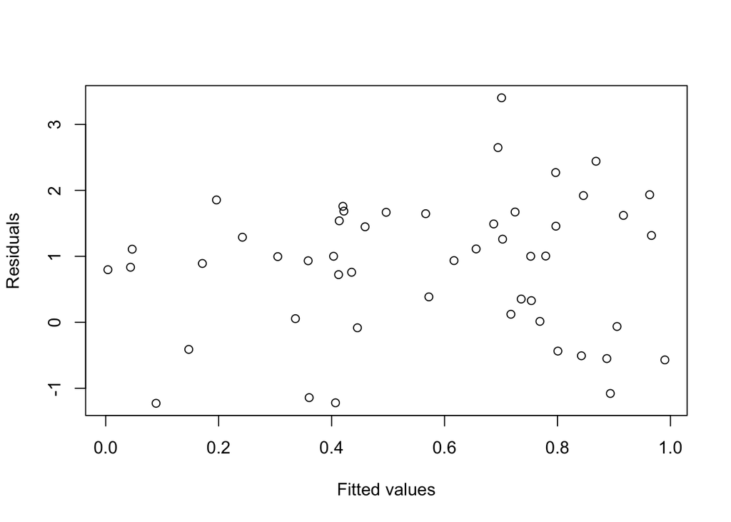

```r
plot(x,cos(x*pi/25)+rnorm(n,sd=1), xlab = "Fitted values", ylab = "Residuals")
```

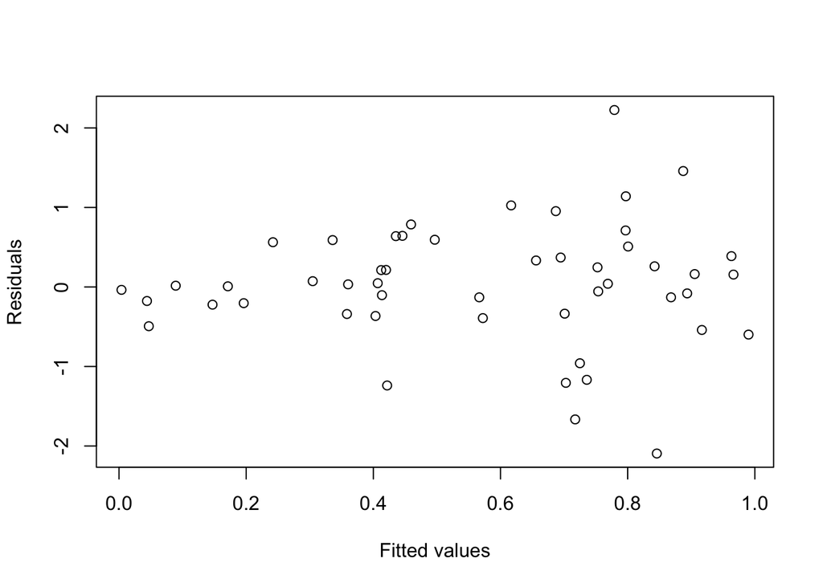

```r
plot(x,sqrt((x))*rnorm(n), xlab = "Fitted values", ylab = "Residuals")
```

### Solution to Question 4

If you want even more practice, run the code block below.

```r
n <- 50
for(i in 1:3) {x <- runif(n) ; plot(x, rnorm(n))}
for(i in 1:3) {x <- runif(n) ; plot(x, x * rnorm(n))}
for(i in 1:3) {x <- runif(n) ; plot(x, sqrt(x) * rnorm(n))}
for(i in 1:3) {x <- runif(n) ; plot(x, cos(x*pi/25) + rnorm(n,sd=3))}
```

## Question 5

Run the code cell below to generate a residuals vs. fitted plot for the full `savings` model.

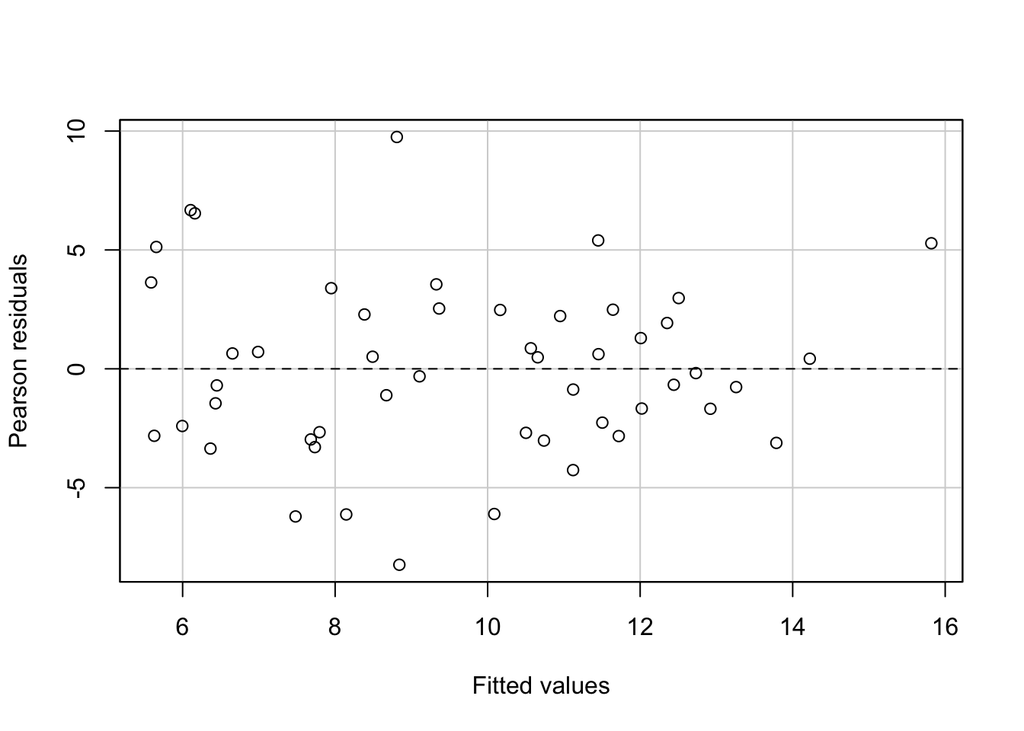

```r
# plot of residuals versus fitted values
residualPlot(lmod, quadratic = FALSE) # We do not want to draw the quad reg
```

Does the constant variance assumption seem to be satisfied?

### Solution to Question 5

The residuals vs. fitted plot indicates the variance seems to be constant with fluctuations likely to due to random variations due to sampling.

## Plotting $\sqrt{|\hat{\epsilon}|}$ Against Fitted Values

If we would like to examine the constant variance assumption more closely, a more powerful way is to plot transformed residuals $\sqrt{|\hat{\epsilon}|}$ against $\hat{y}$. We should first check for nonlinearity.

- For truly normal errors $|\hat{\epsilon}|$ follows a half normal distribution, which is skewed.
- The skewness can be reduced by the square root transformation.
- The effect is that we nearly double the resolution.
- Using `plot()`, set the `which = 3`.

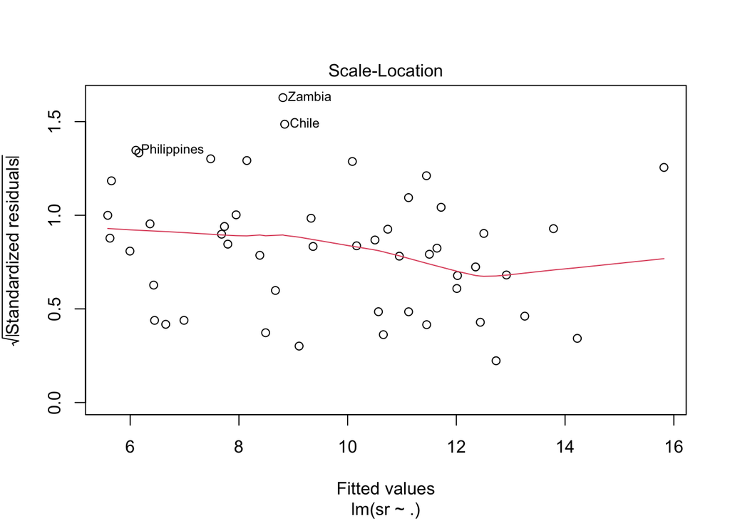

```r
# plot sqrt absolute residuals vs fitted values
plot(lmod, which = 3)
```

## A Statistical Test for Constant Variance

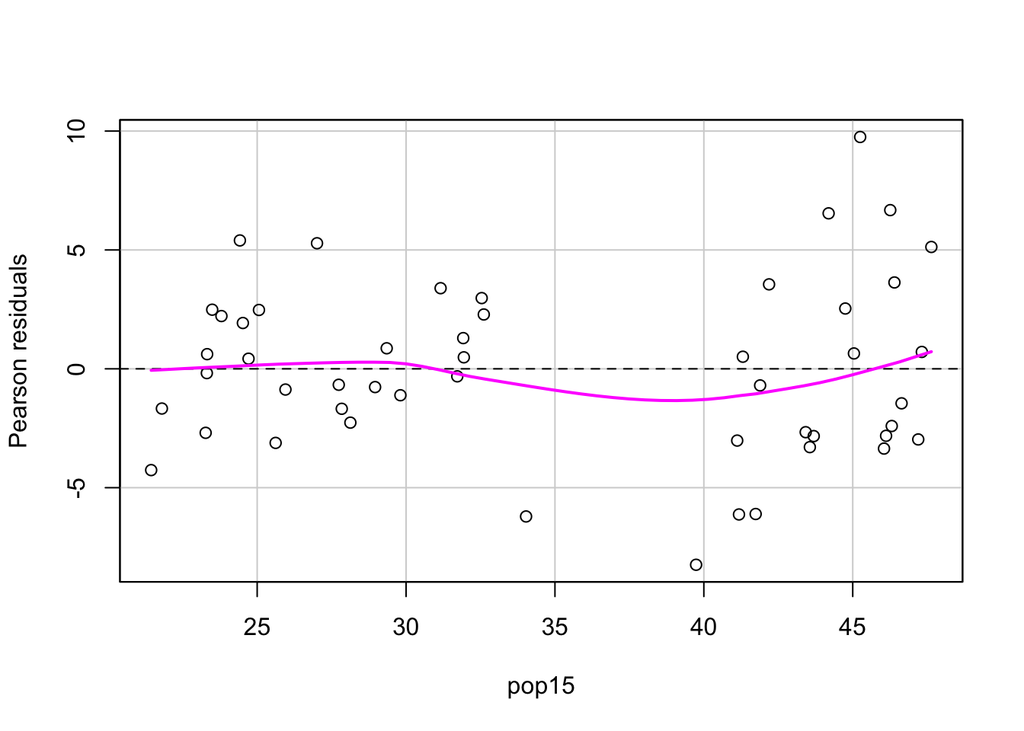

```r
residualPlots(lmod, terms = ~ pop15,
              quadratic = FALSE,  # don't compare with quad model
              fitted = FALSE,  # do NOT plot residuals vs fitted
              smooth = TRUE,  # incude a smoother
              tests = FALSE)  # turn off summary output
```

- $H_0$: The variance of the residuals for `Pop15` $> 35$ and `Pop15` $< 35$ are the same. The ratio of the two variances is equal to 1.
- $H_a$: The variance of the residuals for `Pop15` $> 35$ and `Pop15`$< 35$ are NOT the same. The ratio of the two variances is NOT equal to 1.

We run an F-test to compare to variances (using `var.test`):

```r
var.test(residuals(lmod)[savings$pop15 > 35], residuals(lmod)[savings$pop15 < 35])
```

```
    F test to compare two variances

data:  residuals(lmod)[savings$pop15 > 35] and residuals(lmod)[savings$pop15 < 35]
F = 2.7851, num df = 22, denom df = 26, p-value = 0.01358
alternative hypothesis: true ratio of variances is not equal to 1
95 percent confidence interval:
 1.240967 6.430238
sample estimates:
ratio of variances
          2.785067
```

## Question 6

Based on the output above, what can we say (if anything) about the constant variance assumption? Use a 5% significance level.

### Solution to Question 6

In general:

- If p-value $\leq \alpha$, we reject the null hypothesis.
  - This indicates sufficient evidence to conclude that the **variances are significantly different**.
- If p-value $> \alpha$, we fail to reject the null hypothesis.
  - There is insufficient evidence to conclude the variances are different.
  - It does not mean the variances are definitively equal, only that the data does not provide strong enough evidence to claim the a difference.

Since p-value $= 0.01358 < 0.05$, we reject the null hypothesis. There is sufficient evidence to conclude the constant variance assumption is NOT satisfied.

- This test does not tell us how to fix it!
- Maybe construct two different models? Maybe a transformation of the variables will address this issue?

# Checking Normality of Residuals

Tests and confidence intervals are based on the assumption that the errors are **normally distributed**. **Q-Q plots** are great plots for checking the normality assumption. If the residuals are normally distribution, then the points of a Q-Q plot will lie approximately in a straight line at a $45^{\circ}$ angle.

## What Is a Q-Q Plot?

Histograms and box plots are not as useful for checking normality as a Q-Q plot.

- Box plots can obscure a lot of information.
- The shape of a histogram strongly depends on the number and size of the bins.

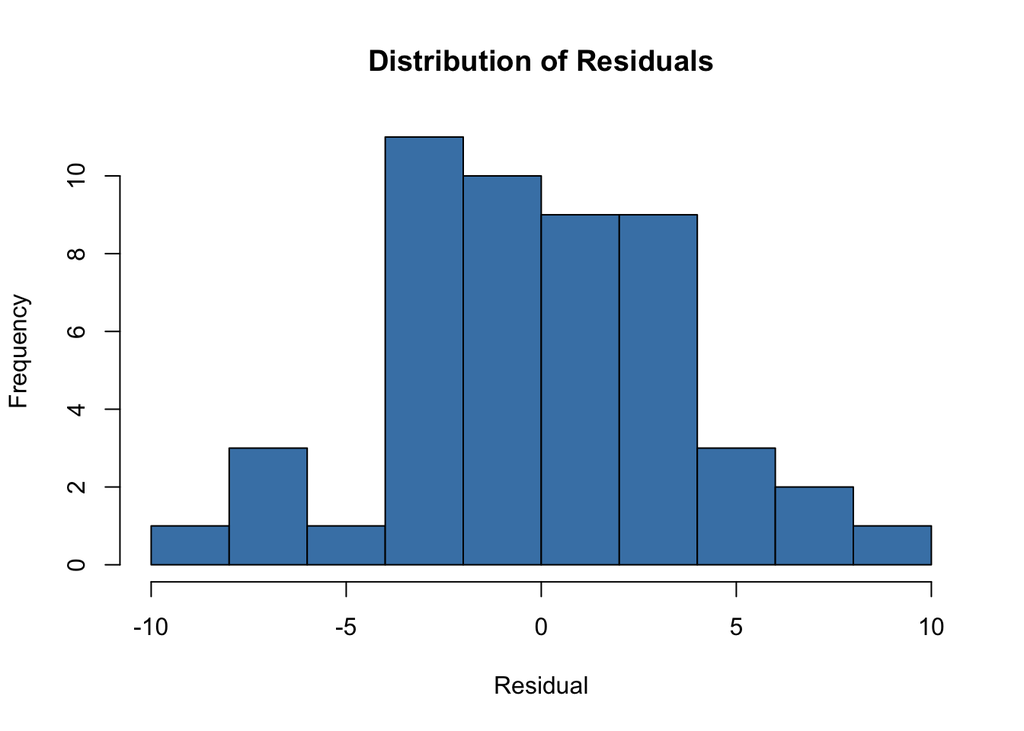

```r
hist(residuals(lmod),
     breaks = 7,
     main = "Distribution of Residuals",
     xlab = "Residual",
     ylab = "Frequency",
     col = "steelblue")
```

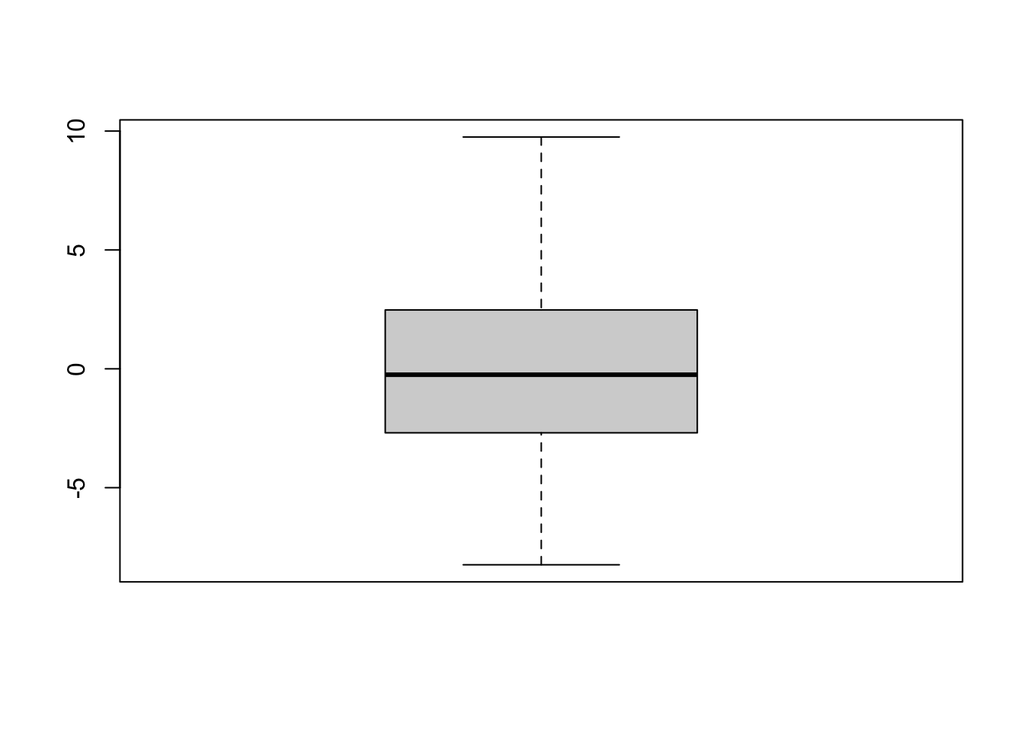

```r
boxplot(residuals(lmod))
```

## Empirical Cumulative Distribution Function

We can calculate the empirical cumulative distribution (ECDF) function for the residuals:

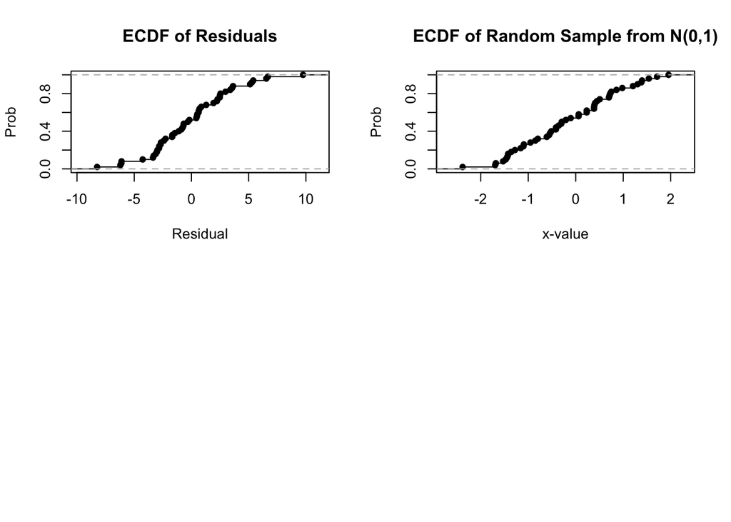

```r
P <- ecdf(residuals(lmod))
par(mfrow = c(2, 2))
plot(P, main = "ECDF of Residuals",
     xlab = "Residual",
     ylab = "Prob")
plot(ecdf(rnorm(50)), main = "ECDF of Random Sample from N(0,1)",
     xlab = "x-value",
     ylab = "Prob")
par(mfrow = c(1, 2))
```

```r
residd <- sort(residuals(lmod))[1:9]
probb <- P(residd)
Q <- qnorm(probb)
```

```r
knitr::kable(data.frame(Residual = c("resid 1", "resid 2", "resid 3", "resid 4", "resid 5", "resid 6", "resid 7", "resid 8", "resid 9"),
Value = residd, Prob = probb, z = Q),
align = "lcr")
```

|  | Residual | Value | Prob | z |
| --- | --- | --- | --- | --- |
| Chile | resid 1 | -8.242231 | 0.02 | -2.0537489 |
| Iceland | resid 2 | -6.210582 | 0.04 | -1.7506861 |
| Paraguay | resid 3 | -6.125759 | 0.06 | -1.5547736 |
| Korea | resid 4 | -6.106981 | 0.08 | -1.4050716 |
| Sweden | resid 5 | -4.260283 | 0.10 | -1.2815516 |
| Guatamala | resid 6 | -3.355284 | 0.12 | -1.1749868 |
| Panama | resid 7 | -3.294166 | 0.14 | -1.0803193 |
| Greece | resid 8 | -3.116169 | 0.16 | -0.9944579 |
| Jamaica | resid 9 | -3.018531 | 0.18 | -0.9153651 |

# We Stopped Here Monday

```r
library(tidyverse)
library(lmtest)  # to access dwtest
library(car)  # for residualPlots and qqPlot
```

The dataset `savings` in the `faraway` package contains savings data from 50 different countries. The variables in the dataset are:

- `sr` is the savings rate, personal saving divided by disposable income.
- `pop15` is the percent of the population under age of 15.
- `pop75` is the percent of the population over age of 75.
- `dpi` is the per-capita disposable income in dollars.
- `ddpi` is the percent growth rate of dpi.

```r
data(savings, package = "faraway") # load data
lmod <- lm(sr ~ ., data = savings) #fit full model
```

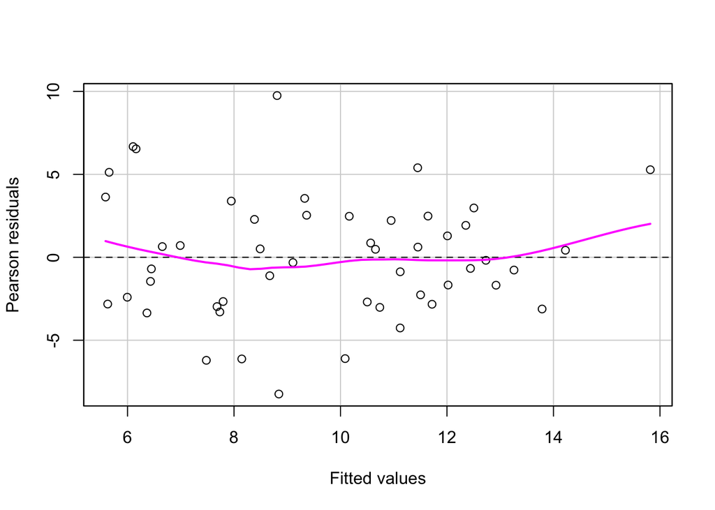

```r
# plot of residuals versus fitted values
residualPlot(lmod, quadratic = FALSE, smooth = TRUE)
```

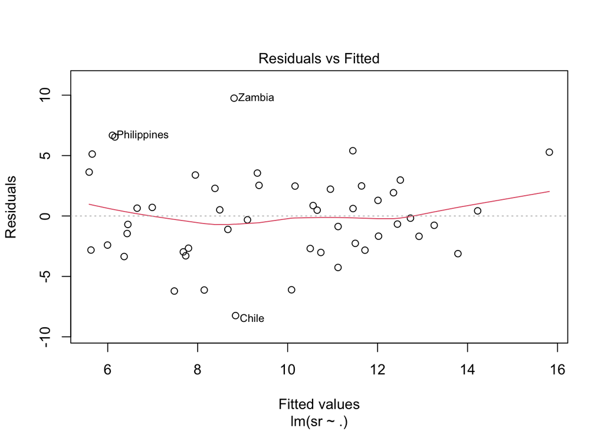

```r
# Another plot of residuals versus fitted values
plot(lmod, which = 1)
```

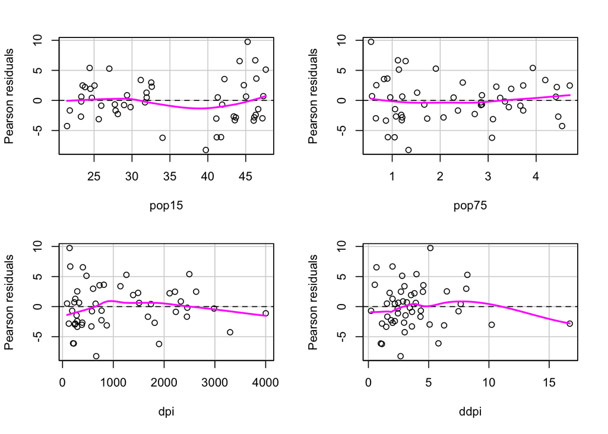

```r
# plot of residuals versus regressors
residualPlots(lmod,
              quadratic = FALSE,  # don't compare with quad model
              fitted = FALSE,  # do NOT plot residuals vs fitted
              smooth = TRUE,  # include a smoother
              tests = FALSE)  # turn off summary output
```

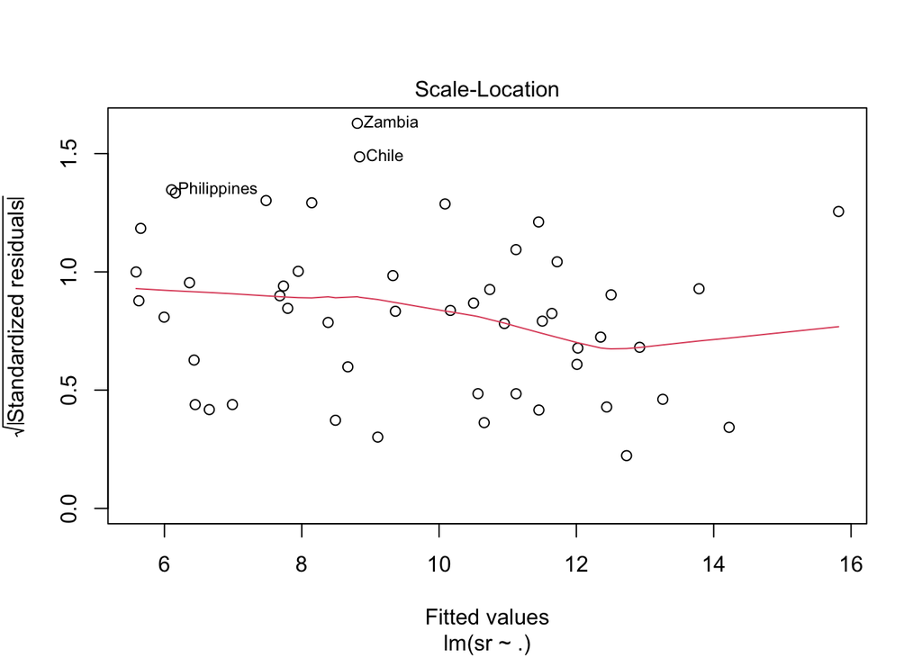

```r
# plot of Standardized residuals versus fitted values
plot(lmod, which = 3)
```

## Creating Q-Q Plots in R

Each point $(z_i, \hat{\epsilon}_i)$ in the plot corresponds to an observation in the data.

- On the $x$-axis we plot $z_i$, the $z$-scores for the sorted residuals if they were normally distributed.
- On the $y$-axis we plot $\hat{\epsilon}_i$, the residual value.
- A reference line is often plotted for comparison with $N(0,1)$

### Using `qqnorm()` and `qqline()` in Base R

In base R, we can use commands `qqnorm()` and `qqline()`.

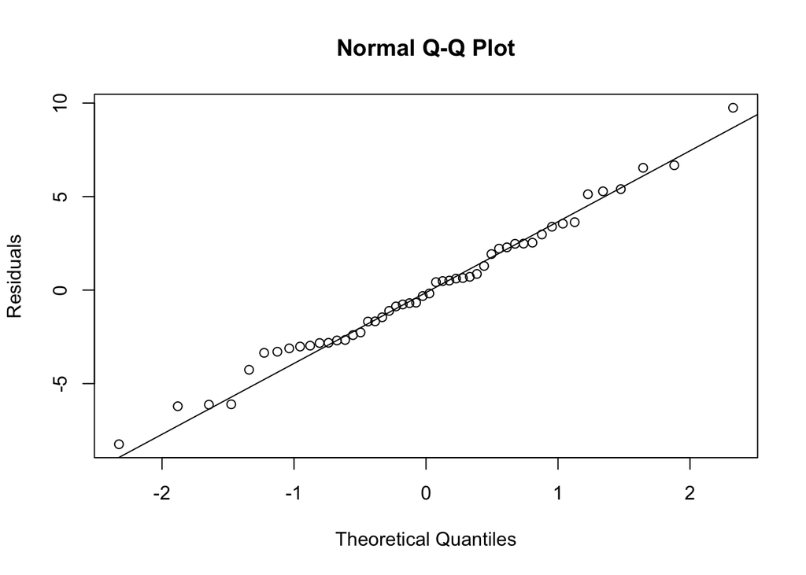

```r
# Using base R
qqnorm(residuals(lmod), ylab = "Residuals")
qqline(residuals(lmod))  # adds reference line to plot
```

### Using `which = 2` Along with `lm` output

We can plot the residuals from the summary output we stored in `lmod`. This will produce a q-q plot for the **standardized residuals**, along with a helpful reference line.

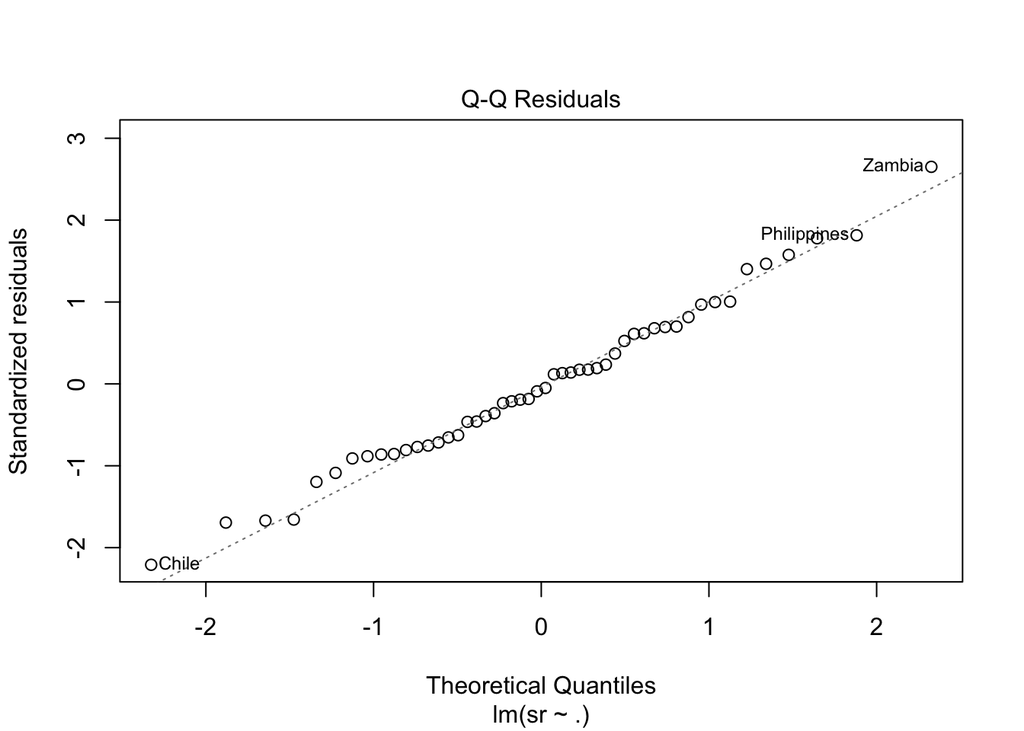

```r
plot(lmod, which = 2)
```

### Using `qqPlot` from `car` Package

The `qqPlot` function from the `car` package is Q-Q plot for the **studentized residuals**, along with pointwise confidence bands for what is expected if $\boldsymbol\epsilon \sim N(0, \sigma^2 I)$.

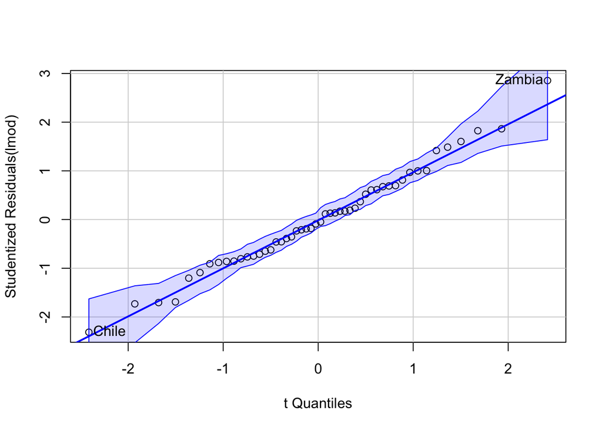

```
 Chile Zambia
     7     46
```

```r
# requires car package
qqPlot(lmod)
```

## Interpreting Q-Q Plots

If the marked points are:

- **Flatter than the line**, there is more data than we’d have if normal.
- **Steeper than the line**, there is less data than we’d have if normal.

## Question 7

Without looking at the histograms, comment on the shape of each sample based on the Q-Q plots below.

### Solution to Question 7

### Plot 1: Normal Data

```r
set.seed(53)
par(mfrow = c(1, 2))
qqPlot(rnorm(50), ylab = "observed data",
       xlab = "normal quantiles", main = "normal data")
```

```
[1] 15  9
```

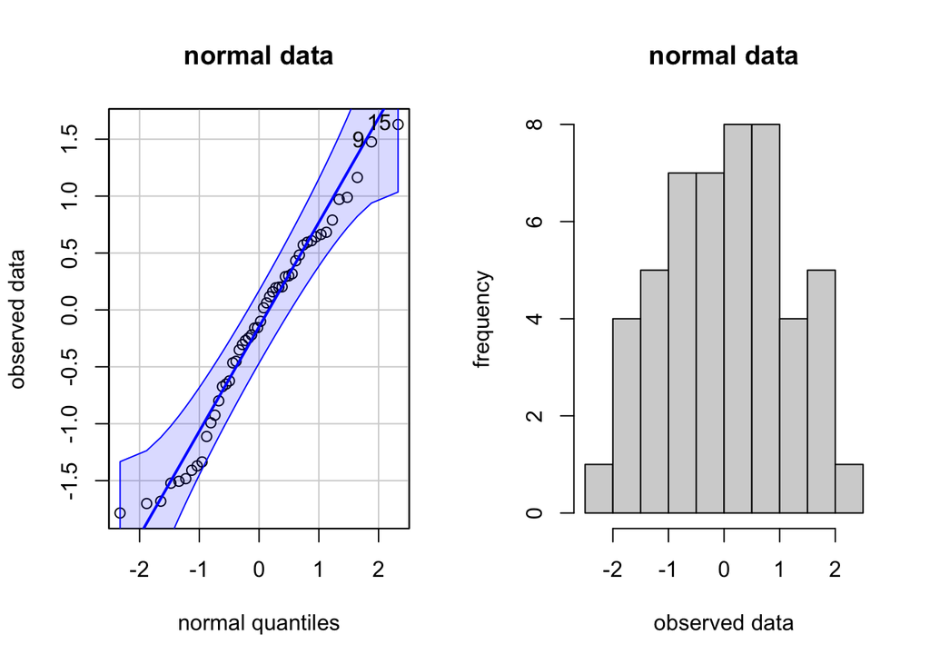

```r
hist(rnorm(50), ylab = "frequency",
       xlab = "observed data", main = "normal data")
```

### Plot 2: Positively skewed data

```r
set.seed(53)
par(mfrow = c(1, 2))
qqPlot(exp(rnorm(50)), ylab = "observed data",
       xlab = "normal quantiles", main = "positively-skewed data")
```

```
[1] 15  9
```

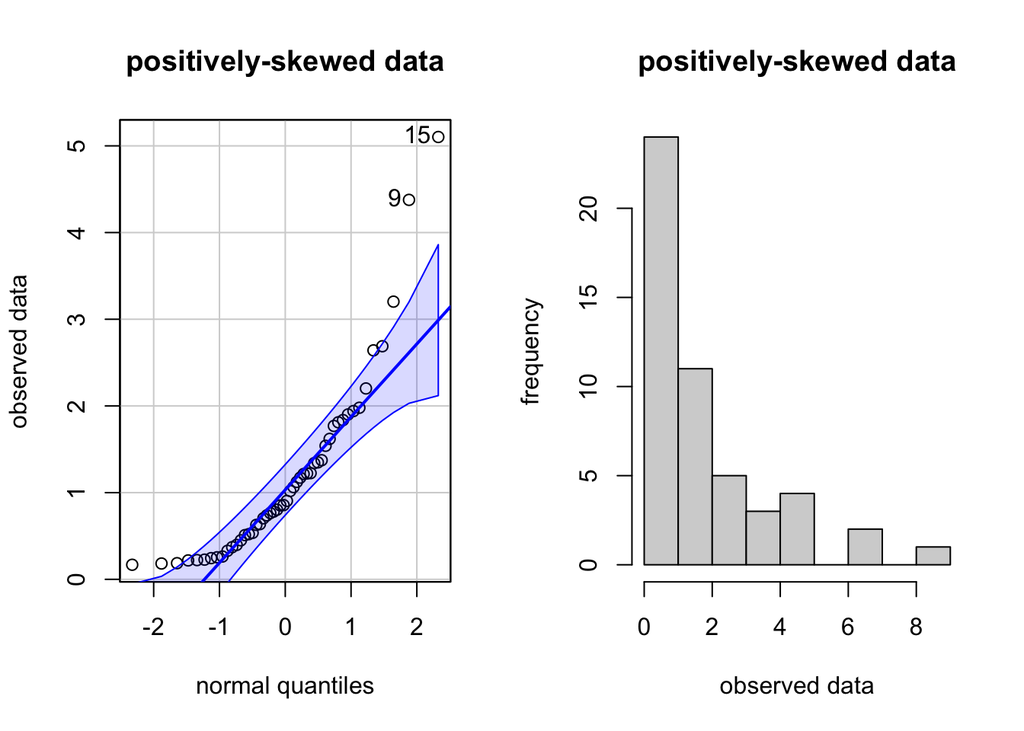

```r
hist(exp(rnorm(50)), ylab = "frequency",
       xlab = "observed data", main = "positively-skewed data")
```

### Plot 3: Heavy Tailed

```r
# Heavy tailed data
# Middle hump taller and more narrow
# Tails go further out to left and right
set.seed(53)
par(mfrow = c(1, 2))
qqPlot(rcauchy(50), ylab = "observed data",
       xlab = "normal quantiles", main = "heavy-tailed data")
```

```
[1] 39 14
```

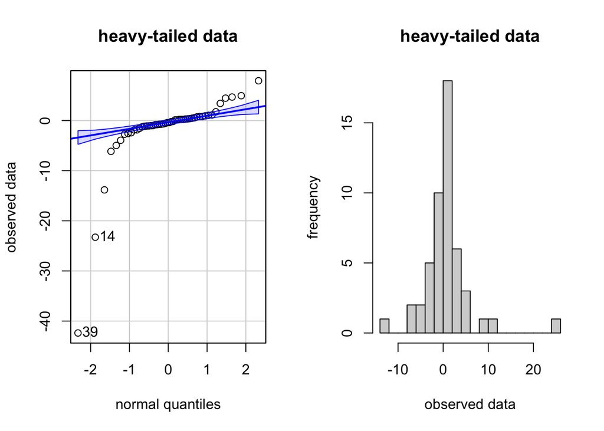

```r
hist(rcauchy(50), ylab = "frequency", breaks = 20,
       xlab = "observed data", main = "heavy-tailed data")
```

### Plot 4: Light Tailed

```r
# Light tailed data
# Middle hump less tall and wider
# Less tails than normal distribution
set.seed(53)
par(mfrow = c(1, 2))
qqPlot(runif(50), ylab = "observed data",
       xlab = "normal quantiles", main = "light-tailed data")
```

```
[1] 29 12
```

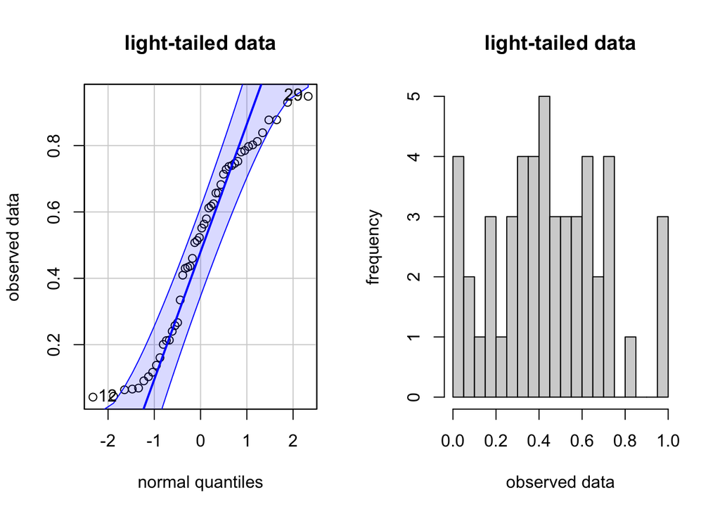

```r
hist(runif(50), ylab = "frequency", breaks = 20,
       xlab = "observed data", main = "light-tailed data")
```

### Plot 5: Skewed Data

```r
# Skewed Data
set.seed(53)
par(mfrow = c(1, 2))
qqPlot(rexp(50), ylab = "observed data",
       xlab = "normal quantiles", main = "Skewed Right")
```

```
[1] 19  8
```

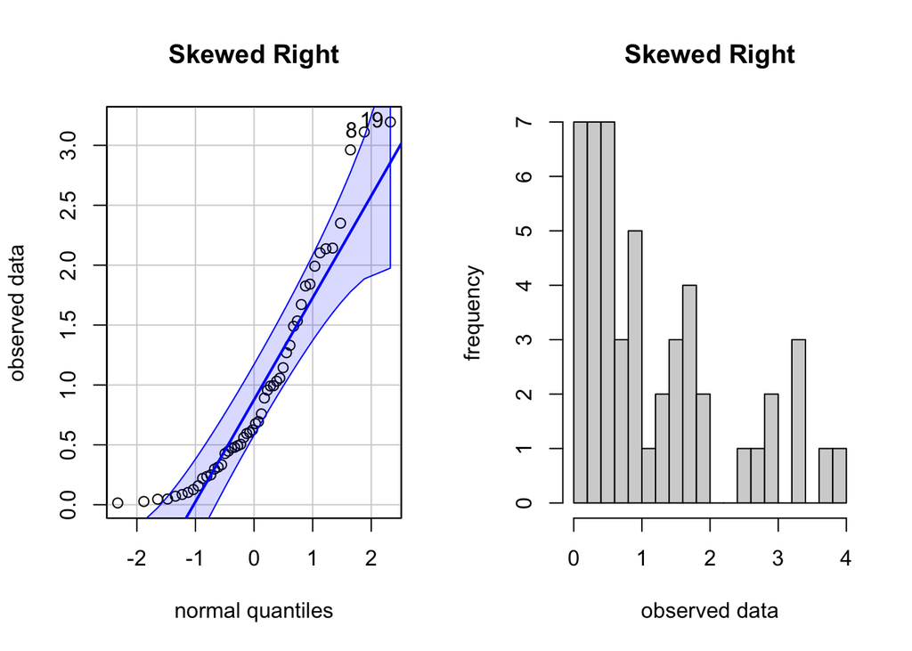

```r
hist(rexp(50), ylab = "frequency", breaks = 20,
       xlab = "observed data", main = "Skewed Right")
```

## The Shapiro-Wilk test for Normality

A formal test of normality can be performed using the **Shapiro-Wilk test**.

- The null hypothesis of the Shapiro-Wilk test is that the residuals are a random sample from a normal distribution.
- The alternative is that the residuals are not a sample from a normal distribution.
- `shapiro.test(residuals(lmod))` will perform a Shapiro-Wilk test.
- A statistical decision is made using the usual approach with p-values.

While the Shapiro-Wilk test is a tidy way to assess normality, it is not as flexible as the Q-Q plot.

- It does not suggest a way to correct the problem.
- It is easily influenced by the number of observations so that even minor departures from normality are detected, even when there is little reason to abandon the least squares approach.

## Question 8

Run the code cell below and interpret the result of this test in practical terms.

```r
shapiro.test(residuals(lmod)) # Shapiro-Wilk test.
```

```
    Shapiro-Wilk normality test

data:  residuals(lmod)
W = 0.98698, p-value = 0.8524
```

### Solution to Question 8

There is insufficient evidence to conclude the residuals come from a non-normal distribution.

## Case Study: Global Warming Data

The dataset `faraway::globwarm` consists of 1001 observations related to the average northern hemisphere temperature from 1856-2000 and eight climate proxies from 1000-2000 AD. Data can be used to predict temperatures prior to 1856.

```r
data(globwarm, package = "faraway")
summary(globwarm)
```

```
     nhtemp             wusa              jasper          westgreen
 Min.   :-0.6200   Min.   :-1.67000   Min.   :-0.9400   Min.   :-1.18000
 1st Qu.:-0.2800   1st Qu.:-0.45000   1st Qu.:-0.0800   1st Qu.:-0.26000
 Median :-0.1500   Median :-0.03000   Median : 0.2400   Median : 0.03000
 Mean   :-0.1203   Mean   : 0.04358   Mean   : 0.1959   Mean   : 0.02878
 3rd Qu.: 0.0300   3rd Qu.: 0.49000   3rd Qu.: 0.4900   3rd Qu.: 0.33000
 Max.   : 0.6600   Max.   : 2.07000   Max.   : 1.5300   Max.   : 1.22000
 NA's   :856
   chesapeake        tornetrask          urals            mongolia
 Min.   :-2.2200   Min.   :-1.7800   Min.   :-1.4900   Min.   :-1.7800
 1st Qu.:-0.9300   1st Qu.:-0.7600   1st Qu.:-0.3800   1st Qu.:-0.2200
 Median :-0.4800   Median :-0.1200   Median :-0.1200   Median : 0.2700
 Mean   :-0.4526   Mean   :-0.1282   Mean   :-0.1041   Mean   : 0.2441
 3rd Qu.: 0.0200   3rd Qu.: 0.3500   3rd Qu.: 0.2700   3rd Qu.: 0.7700
 Max.   : 1.9000   Max.   : 1.7000   Max.   : 0.7300   Max.   : 1.7000

     tasman              year
 Min.   :-1.41000   Min.   :1000
 1st Qu.:-0.20000   1st Qu.:1250
 Median : 0.09000   Median :1500
 Mean   : 0.08479   Mean   :1500
 3rd Qu.: 0.37000   3rd Qu.:1750
 Max.   : 1.21000   Max.   :2000
```

- This is **temporal** data since each observation has an associated time (`year`).
- There are 856 observations prior to 1856 that are missing `nhtemp` values.
  - By default, these observations are omitted from our model (by R)

```r
# we exclude year from the model but include all other regressors
lmod2 <- lm(nhtemp ~ . - year, data = globwarm)
summary(lmod2)
```

```
Call:
lm(formula = nhtemp ~ . - year, data = globwarm)

Residuals:
     Min       1Q   Median       3Q      Max
-0.43668 -0.11170  0.00698  0.10176  0.65352

Coefficients:
             Estimate Std. Error t value Pr(>|t|)
(Intercept) -0.242555   0.027011  -8.980 1.97e-15 ***
wusa         0.077384   0.042927   1.803 0.073647 .
jasper      -0.228795   0.078107  -2.929 0.003986 **
westgreen    0.009584   0.041840   0.229 0.819168
chesapeake  -0.032112   0.034052  -0.943 0.347346
tornetrask   0.092668   0.045053   2.057 0.041611 *
urals        0.185369   0.091428   2.027 0.044567 *
mongolia     0.041973   0.045794   0.917 0.360996
tasman       0.115453   0.030111   3.834 0.000192 ***
---
Signif. codes:  0 '***' 0.001 '**' 0.01 '*' 0.05 '.' 0.1 ' ' 1

Residual standard error: 0.1758 on 136 degrees of freedom
  (856 observations deleted due to missingness)
Multiple R-squared:  0.4764,    Adjusted R-squared:  0.4456
F-statistic: 15.47 on 8 and 136 DF,  p-value: 5.028e-16
```

# Checking for Correlated Errorrs

It is difficult to check for correlated errors because there are so many possible patterns of correlation that may occur. The structure of temporal or spatial data makes this easier to check.

- If the errors $\boldsymbol\epsilon$ are uncorrelated, then the residuals $\hat{\boldsymbol\epsilon}$ are typically close to uncorrelated.

## Plotting Residuals Against Time

If the errors are uncorrelated, we expect a random scatter of points around $\hat{\epsilon}=0$.

## Question 9

Run the code cell below to plot the residuals of `lmod2` against `year`. Do you notice any correlation in the errors?

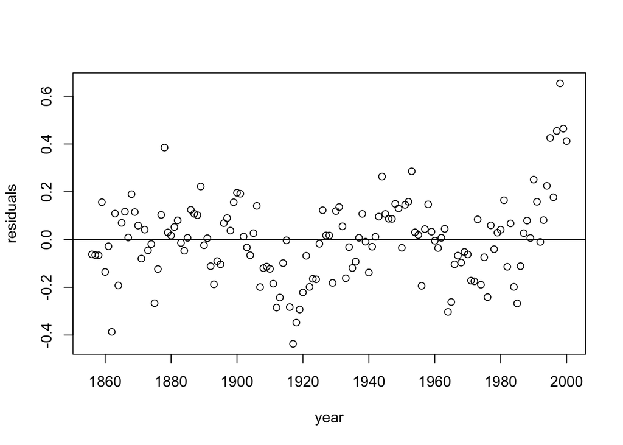

```r
# residuals vs time
plot(residuals(lmod2) ~ year,
     data = na.omit(globwarm), ylab = "residuals")
abline(h = 0)
```

### Solution to Question 9

There seems to be a cyclical pattern to the residuals over time.

- A positive error in one period carries over into a positive error in the next year.
- A negative error in one year carries over to a negative error in the next year.
- This suggests a correlation among the residuals.

## Plotting Successive Pairs of Residuals

Another approach to check for serial correlation is to plot successive pairs of residuals.

## Question 10

Run the code cell below to plot successive pairs of residuals. Interpret the plot. How does this confirm a positive serial correlation?

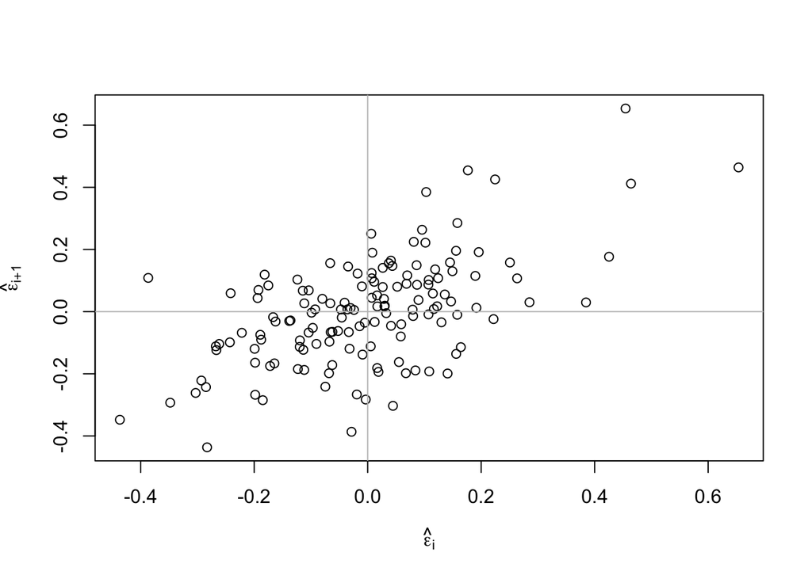

```r
n <- nobs(lmod2)
plot(tail(residuals(lmod2), n - 1) ~      # extracts (e_2, e_3, ..., e_50)
      head(residuals(lmod2), n - 1),      # extracts (e_1, e_2, ..., e_49)
     xlab = expression(hat(epsilon)[i]),
     ylab =expression(hat(epsilon)[i+1]))
abline(h= 0 , v = 0, col = grey(0.75))
```

### Solution to Question 10

- The positive linear trend in the previous plot suggests positive serial correlation.
- If there was no association, we would expect a cloud of points.

## The Durbin-Watson Test for Uncorrelated Errors

A formal test for serial correlation between residuals can be performed using the **Durbin-Watson test**.

Let $\rho$ denote the serial correlation between residuals. The hypotheses are:

- $H_0$: The residuals are uncorrelated, $\rho = 0$.
- $H_a$: The residuals are related in some way ($\rho \ne 0$, $\rho > 0$, or $\rho < 0$).

The test statistic is:

$$DW = \frac{\sum_{i=2}^n(\hat{\epsilon}_i - \hat{\epsilon}_{i-1})^2}{\sum_{i=1}^n \hat{\epsilon}_i^2}$$

The test can be implemented in the `lmtest` package.

```r
#library(lmtest)
dwtest(lmod2, alternative = "greater")  # note greater is the default
```

```
    Durbin-Watson test

data:  lmod2
DW = 0.81661, p-value = 1.402e-15
alternative hypothesis: true autocorrelation is greater than 0
```

## Question 11

Interpret the result of this test in the previous code cell in practical terms.

### Solution to Question 11

We can reject the null hypothesis and we have significant evidence in support of the alternative hypothesis that the residuals have a positive serial correlation.

## Summary of Checking for Correlated Errors

- **Generalized least squares** (which takes into account dependence) can be used for data with correlated errors.
- When there is no apparent temporal or spatial link between observations, it is almost impossible to check for correlation between errors. On the other hand, there is generally no reason to suspect it either!

# Practice Example: A Model for SAT Scores

## Build an Initial Model

Using the `sat` dataset in the `faraway` package, fit a model with the total SAT score as the response and `expend`, `salary`, `ratio`, and `takers` as predictors.

```r
data(sat, package = "faraway")
summary(sat)
```

```
     expend          ratio           salary          takers
 Min.   :3.656   Min.   :13.80   Min.   :25.99   Min.   : 4.00
 1st Qu.:4.882   1st Qu.:15.22   1st Qu.:30.98   1st Qu.: 9.00
 Median :5.768   Median :16.60   Median :33.29   Median :28.00
 Mean   :5.905   Mean   :16.86   Mean   :34.83   Mean   :35.24
 3rd Qu.:6.434   3rd Qu.:17.57   3rd Qu.:38.55   3rd Qu.:63.00
 Max.   :9.774   Max.   :24.30   Max.   :50.05   Max.   :81.00
     verbal           math           total
 Min.   :401.0   Min.   :443.0   Min.   : 844.0
 1st Qu.:427.2   1st Qu.:474.8   1st Qu.: 897.2
 Median :448.0   Median :497.5   Median : 945.5
 Mean   :457.1   Mean   :508.8   Mean   : 965.9
 3rd Qu.:490.2   3rd Qu.:539.5   3rd Qu.:1032.0
 Max.   :516.0   Max.   :592.0   Max.   :1107.0
```

```r
# fit model
lmod3 <- lm(total ~ expend + salary + ratio + takers, data = sat)
summary(lmod3)
```

```
Call:
lm(formula = total ~ expend + salary + ratio + takers, data = sat)

Residuals:
    Min      1Q  Median      3Q     Max
-90.531 -20.855  -1.746  15.979  66.571

Coefficients:
             Estimate Std. Error t value Pr(>|t|)
(Intercept) 1045.9715    52.8698  19.784  < 2e-16 ***
expend         4.4626    10.5465   0.423    0.674
salary         1.6379     2.3872   0.686    0.496
ratio         -3.6242     3.2154  -1.127    0.266
takers        -2.9045     0.2313 -12.559 2.61e-16 ***
---
Signif. codes:  0 '***' 0.001 '**' 0.01 '*' 0.05 '.' 0.1 ' ' 1

Residual standard error: 32.7 on 45 degrees of freedom
Multiple R-squared:  0.8246,    Adjusted R-squared:  0.809
F-statistic: 52.88 on 4 and 45 DF,  p-value: < 2.2e-16
```

## Check Error Assumptions

Perform regression diagnostics on this model to answer the following questions.

### Check the mean-zero error assumption.

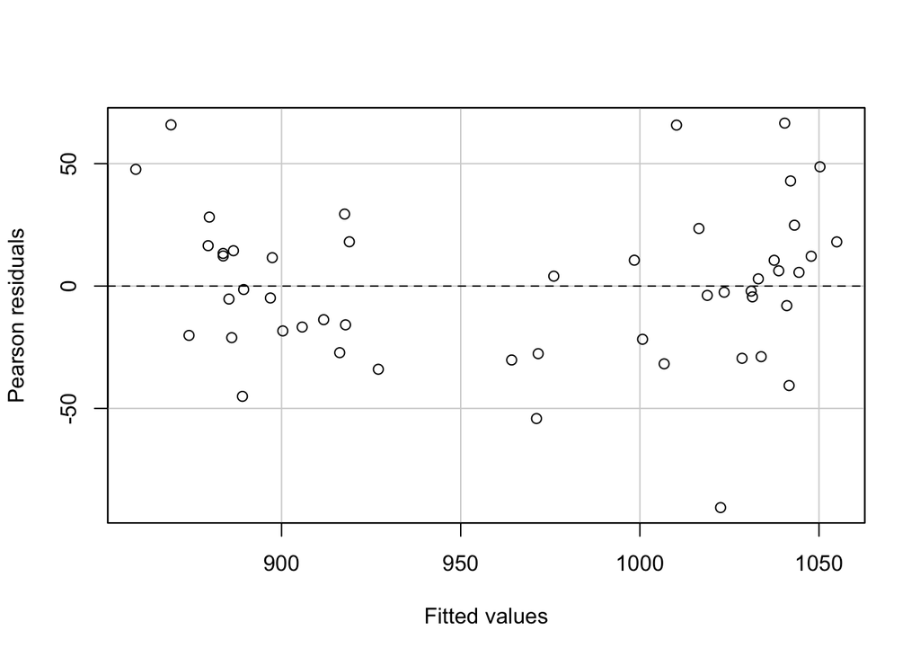

```r
# plot residuals vs fitted values.
residualPlot(lmod3, quadratic = FALSE)
```

- This assumptions seems to be satisfied. There is one prediction which had a large (negative) residual, but that is likely due to variability in sampling and not a violation of this assumption.